# Econ 203: Lab Session 1

Marcelino Guerra

1/21/2020

## Review #1 Question 1

The manager of a men’s store observes the waist size (in inches) of trousers sold yesterday:

**32,32,33,40,32,48,34,33,30,28**

Calculate the range, variance, and standard deviation of these data. Select the answers equal to or closest to your results.

Range = ?

Variance = ?

Standard Deviation = ?

What percentage of the observations are within 1, 2 and 3 standard deviations of the mean?

Within ±1 standard deviation: =

Within ±2 standard deviation: =

Within ±3 standard deviation: =

How does this compares with what the empirical rule predicts?

### Answer

#### Working with vectors

A vector is a sequence of data elements of thesame basic type - in our case, numbers (a numeric vector). So, use “c()”.

Giving it a name (waist):

```r
waist<-c(32,32,33,40,32,48,34,33,30,28)
View(waist)
```

It has a skewed distribution!

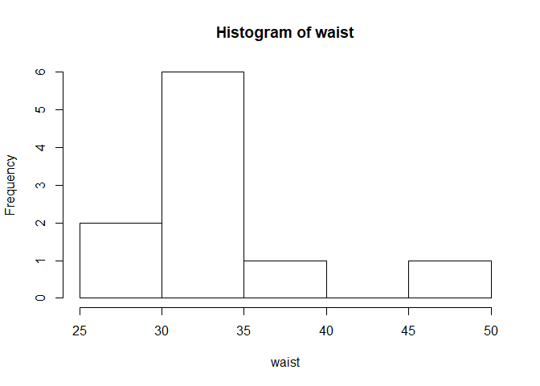

```r
hist(waist)
```

All that you need to answer the first part of the question: sd() and mean().

```r
mean<-mean(waist)
sd<-sd(waist)
mean
```

```
## [1] 34.2
```

```r
sd
```

```
## [1] 5.750362
```

Time to construct intervals using ifelse function. Give them a name!

**$1^{st}$ interval**

```r
fi<-ifelse((mean-1*sd)<=waist & waist<=(mean+1*sd), 1,0)
View(fi)
## How many observations fit inside the interval?
## (In other words) How many ones do you have?
sum(fi)
```

```
## [1] 7
```

Don’t forget to calculate the proportion!

```r
prp1st<-sum(fi)/10
prp1st
```

```
## [1] 0.7
```

**$2^{nd}$ interval**

```r
si<-ifelse((mean-2*sd)<=waist & waist<=(mean+2*sd), 1,0)
prp2nd<-sum(si)/10
prp2nd
```

```
## [1] 0.9
```

**$3^{rd}$ interval**

```r
ti<-ifelse((mean-3*sd)<=waist & waist<=(mean+3*sd), 1,0)
prp3rd<-sum(ti)/10
prp3rd
```

```
## [1] 1
```

Time to compare with what the [empirical rule](https://en.wikipedia.org/wiki/68%E2%80%9395%E2%80%9399.7_rule) predicts.